# Data Wrangling Using the Quality of Bananas

Katie Repoli

March 25, 2024

# Introduction

I will be using [Banana Quality](https://www.kaggle.com/datasets/l3llff/banana) data to teach you how to wrangle data. This data set contains the **size, weight, sweetness, softness, harvest time, ripeness, and acidity** of 8,000 bananas. Each of these components determine the overall **quality** of the banana, specifically whether it is good or bad. I will first focus on the select(), filter(), and count() functions, followed by group_by(), and summarize(). These are all included within the tidyverse package. Click “show” to see my code.

## Select, Filter, and Count

```r
ripeness_positive <- banana_quality %>%
  select(Ripeness, Quality) %>%
  filter(Ripeness >= 0)
```

I have printed the first 10 rows as to not take up the entire page. In reality, there are 5,347 rows.

```
##    Ripeness Quality
## 1  2.435570    Good
## 2  2.067549    Good
## 3  3.090643    Good
## 4  1.873001    Good
## 5  1.078345    Good
## 6  2.079410    Good
## 7  1.348143    Good
## 8  2.395917    Good
## 9  1.311802    Good
## 10 3.889359    Good
```

I used the select() function to choose specific columns from the data: Ripeness and Quality. I then filtered the Ripeness column to only show bananas whose ripeness is above or equal to 0. I basically removed all negative numbers. My prediction was that most of the bananas whose ripeness was positive would be a good-quality banana because ripe bananas typically taste better.

```r
ripeness_positive %>%
  count(Quality, sort=T)
```

```
##   Quality    n
## 1    Good 3309
## 2     Bad 2038
```

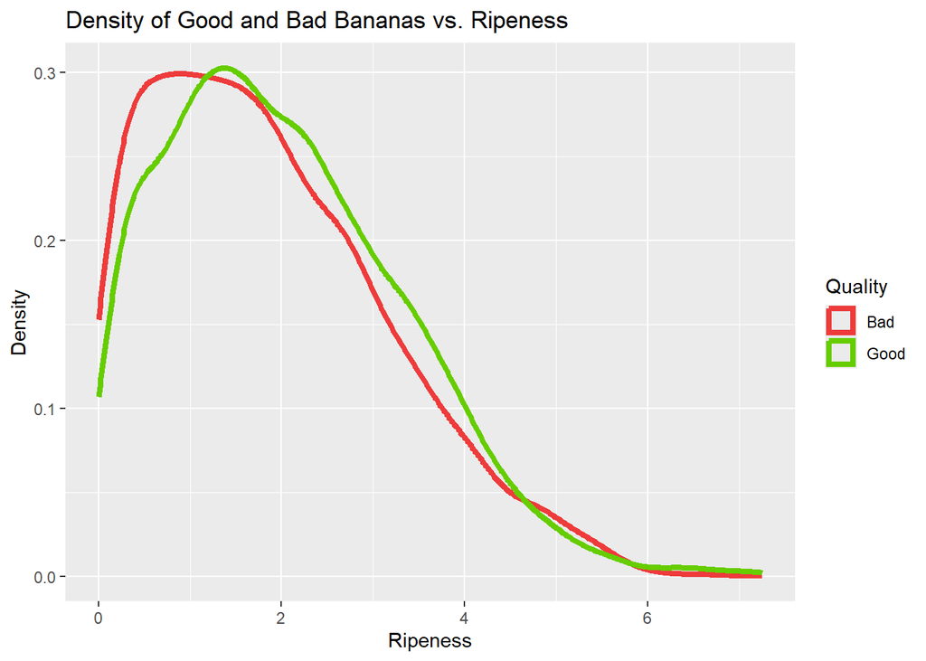

```r
ggplot(data=ripeness_positive, aes(x=Ripeness))+
  geom_density(aes(color=Quality), size=1.5)+
  labs(y="Density", title="Density of Good and Bad Bananas vs. Ripeness")+
  scale_color_manual(values = c("brown2", "chartreuse3"))
```

## Summarize and Group_by

```r
good_vs_bad <- banana_quality %>%
  group_by(Quality) %>%
  summarize(num_bananas = n(),
            avg_sweetness = mean(Sweetness, na.rm=T),
            avg_softness = mean(Softness, na.rm=T),
            avg_ripeness = mean(Ripeness, na.rm=T))
good_vs_bad
```

```
## # A tibble: 2 × 5
##   Quality num_bananas avg_sweetness avg_softness avg_ripeness
##   <chr>         <int>         <dbl>        <dbl>        <dbl>
## 1 Bad            3994       -1.51        -0.0111       0.0390
## 2 Good           4006       -0.0364      -0.0178       1.52
```

I used the group_by() function to determine that I would like to summarize data based on the quality of the banana. This function seperates the good and bad bananas from each other to determine the average for both individually. I then used the summarize function to find the count of good and bad bananas, as well as the mean sweetness, softness, and ripeness for both qualities of banana. I determined that there are around the same number of good and bad bananas, but good bananas were typically sweeter and riper. Both banana qualities had around the same softness.